# 浅野ゼミ春合宿 2018年

2018年5月19日から20日にかけて、山梨県南都留郡鳴沢村にて2018年度浅野ゼミナール春合宿が行われました。今回のゼミ合宿では、2年生から4年生まで計22名が参加し、親睦を深めることができました。

[figure not shown]

富士緑の休暇村で記念撮影

茗荷谷駅から宿泊先へ向かうバスの中では、学年の垣根を越えて様々な話で盛り上がり、ゼミ生同士の仲を深めることができました。宿泊先である富士緑の休暇村に到着後、ゼミ生同士の顔合わせも兼ねて2年生から4年生まで一人ひとり自己紹介をしました。その後、ゼミ論文のテーマ発表を行い、夕食時間まで各自自由に過ごしました。温泉を楽しんだり、部屋でUNOやトランプをする学生もいました。今回の春合宿は２日間とても天気が良かったので、外で散歩を楽しむ学生も多かったです。

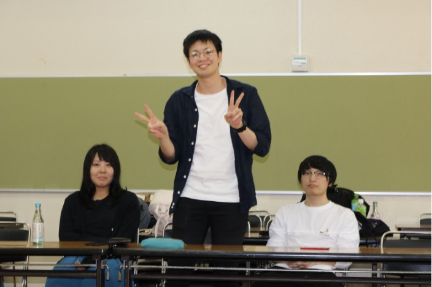

自己紹介の様子

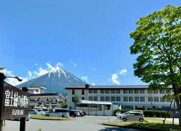

施設の外観

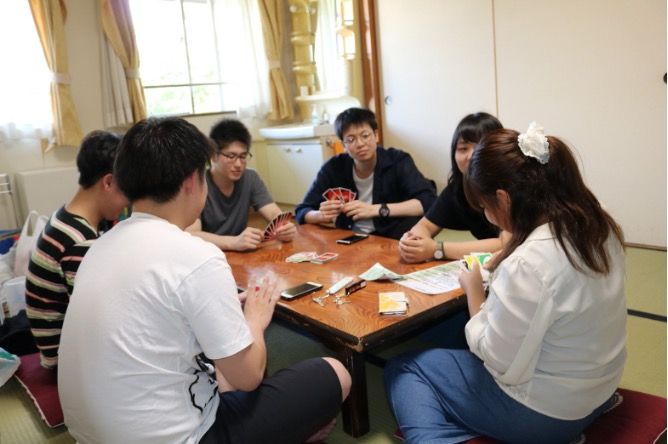

UNOやトランプに興じる人々

夕食はバーベキューだったので、普段よりも近い距離で友人、先輩、後輩たちと食事を楽しむことができました。食事が終わった頃、夕日に映えた富士山がとても綺麗だったので、皆で写真撮影をして盛り上がりました。その後、大浴場や露天風呂で日々の疲れを癒しながら様々な話をして過ごしました。

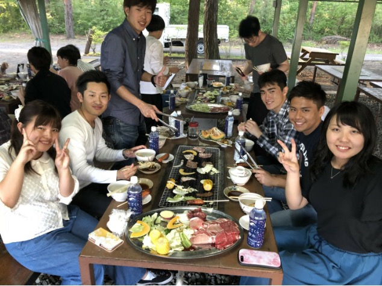

バーベキューの様子

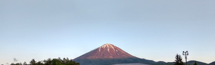

夕日に照らされた富士山

入浴後は親睦会とビンゴ大会を開催しました。親睦会は普段あまり話すことのない他学年のゼミ生と長い時間話すことができる貴重な時間だったので、進路や趣味など様々な話をすることができました。ビンゴ大会では大学生活で実際に使える便利グッズから、自宅で楽しめる物まで様々な景品が用意され、大いに盛り上がりました。

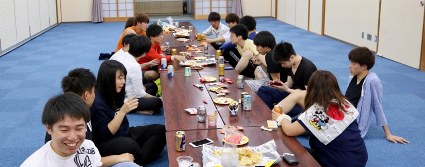

親睦会の様子

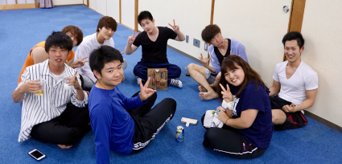

浅野ゼミ2年生の皆さん

[figure not shown]

翌朝、朝食を済ませてから合宿施設の近くで集合写真を撮りました。解散後、少し肌寒かったですが、ゼミ生同士で富士急ハイランドへ行って楽しみました。学年の垣根を超えてゼミ生の皆さんと長い時間を共に過ごすという機会はなかなか無かったので、とても充実した合宿になりました。 （文責：政経学部 法律政治学科 3年 西村くるみ）

#### 政経学部 法律政治学科 2年 飯島千尋

今回、春合宿を企画、運営してくださった３年の先輩方、ありがとうございました。春合宿に参加するまでは、ゼミが始まって間もないということも、あり先輩方や同学年の人とも話す機会がなかなかなかったので、不安や緊張でいっぱいでした。しかし、先生や先輩方、同学年の方みんなが優しく接してくれたため、心温まる時間を終始過ごすことができました。また、BBQやビンゴ大会などの楽しい企画を通じて色々な話をすることにより徐々に仲を深めることができ、とても嬉しかったです。この合宿に参加したことで、浅野ゼミに入って良かったと改めて心から思いました。

#### 政経学部 法律政治学科 3年 名村啓

今回の春合宿は、富士山が近くで見えて空気が美味しい素敵な宿泊施設に泊まりました。そんな最高の環境で夕飯はバーベキューをして盛り上がりました。温泉も気持ちよく、風呂から見える景観も素晴らしかったです。懇親会では2年生の意外な一面を垣間見ることができ、仲を深めることができました。

#### 政経学部 経済学科 ４年 吉田 翔

今年の春合宿も、ゼミ生同士が学年の垣根を超えて交流を行う実りあるものになりました。 ２年生とは通常のゼミナールで顔を合わせる事が無い為、「お互いの顔と名前を一致させる」という極めて初歩的な人間関係から合宿がスタートしましたが、思いも寄らぬアクシデントや楽しいイベントを経て、合宿が終わる頃にはすっかり打ち解けた感じでした。 ３年生とは常日頃ゼミナールで顔を合わせているものの、合宿で普段は窺い知ることの出来ないプライベートな一面を知り、普段とは違った角度から関係を深められたと思います。 良好な人間関係は、忌憚のない意見を交わし合う有意義かつ効果的な議論を行い易くします。今回の合宿で深めた関係を、今後は論文制作の一助にしていきたく思います。 最後に、先生・幹事の方を始め、この合宿を作り上げてくださったゼミ生全員に感謝致します。本当に有難うございました。